# Homework 8

Anthony Cunningham

April 10, 2019

# 1 Air Pollution Data

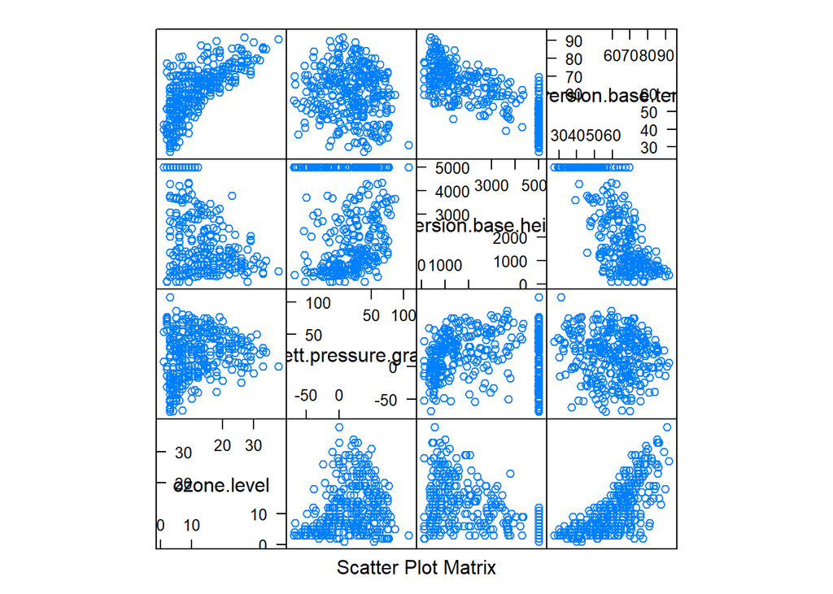

Using this scatter plot matrix of California Air Pollution Data in 1976, one can notice a clear trend between Ozone Level and Inversion Base Temperature, in that as the Temperature increases, Ozone Level tends to accelerate, or increase at a faster rate. Another trend one may notice between Inversion Base Height and Daggett Pressure Gradient is that, as Height increases, Pressure Gradient tends to increase, but at a decreasing rate. However, this relationship does appear to be noisy, especially at higher values of Height. I noticed this moreso from the densities of the points at lower levels of Height, where Pressure Gradient initially increased at a high rate, but slowed down at a Height of about 1000 feet or so. One more trend that I notice is that Inversion Base Temperature tends to decrease as Height increases, though with some pretty notable outliers at the highest value of Height, 5000 feet, where some temperatures are between 60 and 70 degress Fahrenheit, which appears odd.

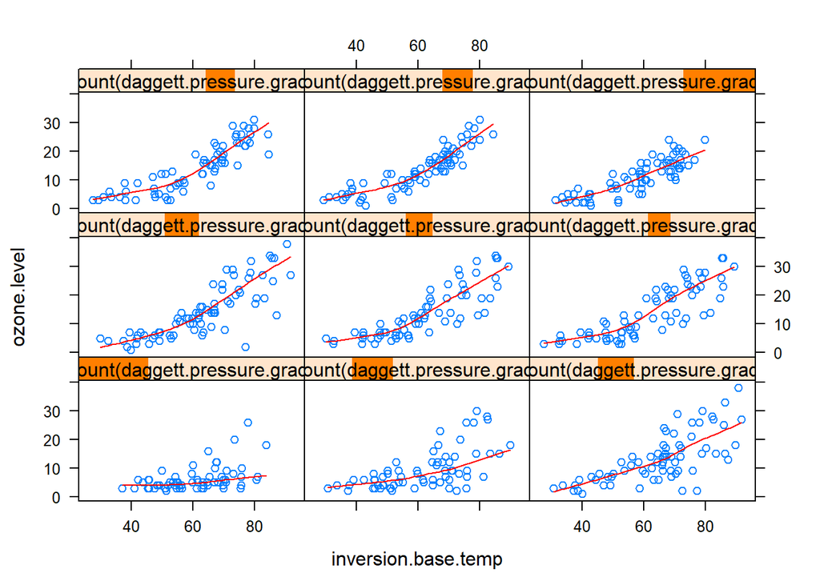

Using this Conditioning Plot of Ozone Levels vs Inversion Base Temperatures, conditioned on Daggett Pressure Gradients, one notices that upward trends of Ozone Levels with respect to higher Temperatures are more pronounced for moderate values of Pressure Gradient. For high and low levels, especially, of Pressure Gradient, Ozone Levels tend to increase as Temperature increases, but at much lower magnitudes, especially at the low end of Pressure Gradient.

# 2 Olive Oils

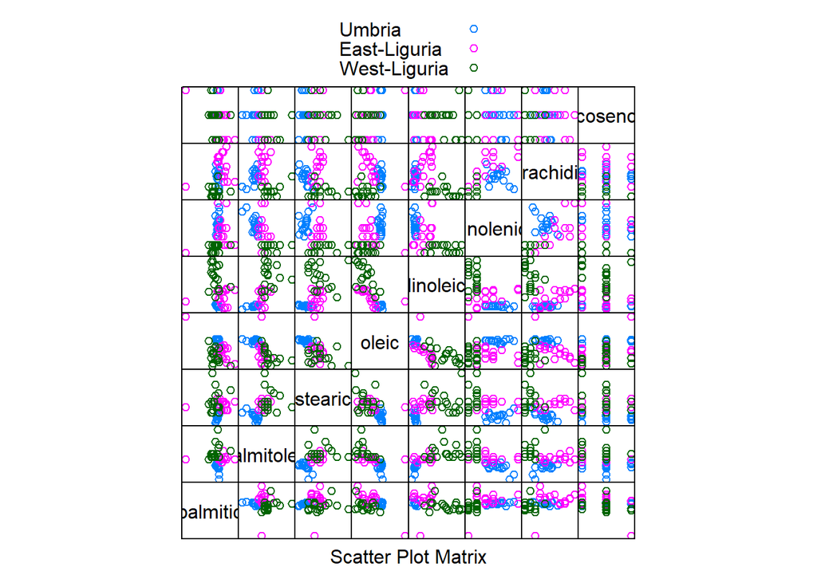

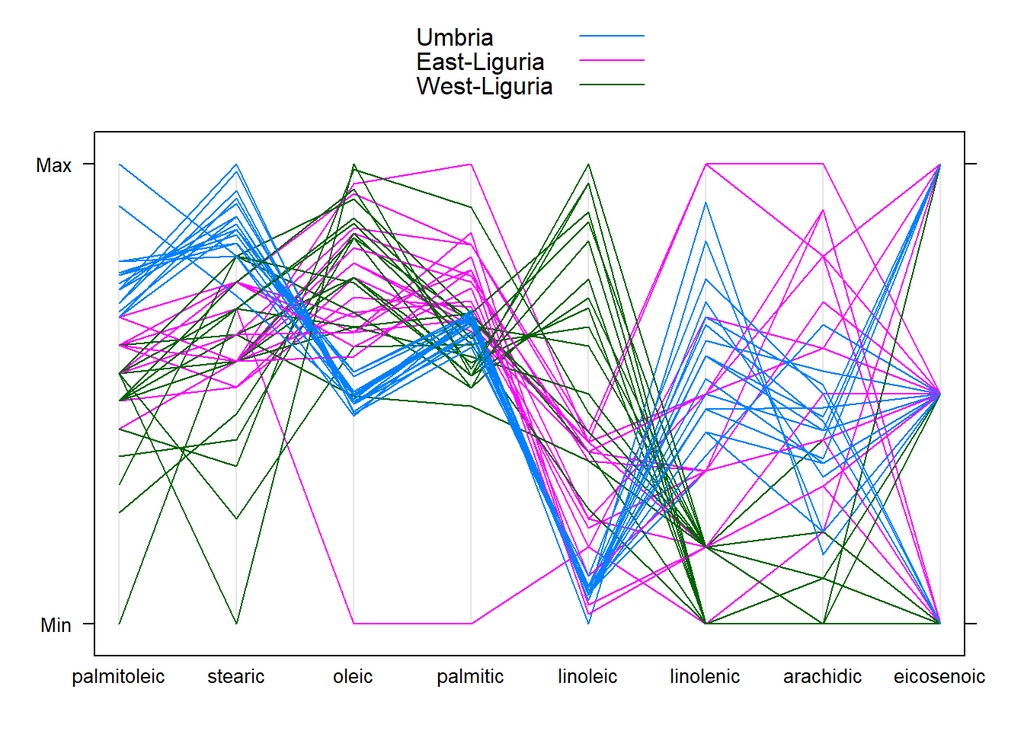